# Assignment 5

Reginald Mordi

- Hierarchical clustering to a dataset Cereals

```r
library(devtools)
library(htmltools)
library(caret)
library(ISLR)
library(dplyr)
library(ggvis)
library(cluster)
```

```r
library(dendextend)
library(factoextra)
library(class)
library(FNN)
```

```r
library(ggplot2)
library(e1071)
```

# Reading Data

```r
#Read Data
cereals <- read.csv("Cereals.csv")

#Remove all records with missing measurements from the dataset.
cer <- na.omit(cereals)
```

# Data Pre-processing

```r
# checking the frequency of each record
counts<-as.data.frame(table(cer[1]))
head(counts)
```

```
##                        Var1 Freq
## 1                 100%_Bran    1
## 2         100%_Natural_Bran    1
## 3                  All-Bran    1
## 4 All-Bran_with_Extra_Fiber    1
## 5   Apple_Cinnamon_Cheerios    1
## 6               Apple_Jacks    1
```

```r
# as we see that the records are unique
```

- so we will Convert the names of the breakfast cereals to the row names, as this will later help us in visualising the clusters

```r
# set row names to the cereals names
rownames(cer) <- cer$name

# Drop the name column as it is now just redundant information
cer$name = NULL

# we will use the continuous numerical values, and applying the euclidean distance method
cer_numeric <- cer[,-c(1,2)]
str(cer_numeric)
```

```
## 'data.frame':    74 obs. of  13 variables:
##  $ calories: int  70 120 70 50 110 110 130 90 90 120 ...
##  $ protein : int  4 3 4 4 2 2 3 2 3 1 ...
##  $ fat     : int  1 5 1 0 2 0 2 1 0 2 ...
##  $ sodium  : int  130 15 260 140 180 125 210 200 210 220 ...
##  $ fiber   : num  10 2 9 14 1.5 1 2 4 5 0 ...
##  $ carbo   : num  5 8 7 8 10.5 11 18 15 13 12 ...
##  $ sugars  : int  6 8 5 0 10 14 8 6 5 12 ...
##  $ potass  : int  280 135 320 330 70 30 100 125 190 35 ...
##  $ vitamins: int  25 0 25 25 25 25 25 25 25 25 ...
##  $ shelf   : int  3 3 3 3 1 2 3 1 3 2 ...
##  $ weight  : num  1 1 1 1 1 1 1.33 1 1 1 ...
##  $ cups    : num  0.33 1 0.33 0.5 0.75 1 0.75 0.67 0.67 0.75 ...
##  $ rating  : num  68.4 34 59.4 93.7 29.5 ...
```

- Variable ‘shelf’ is a categorical variable. Lets convert appropriately.

```r
cer_numeric$shelf <- as.factor(cer_numeric$shelf)
#install.packages("dummies")
library(dummies)
cerdummy <- dummyVars(~shelf,data=cer_numeric)
head(predict(cerdummy,cer_numeric))
```

```
##                           shelf.1 shelf.2 shelf.3
## 100%_Bran                       0       0       1
## 100%_Natural_Bran               0       0       1
## All-Bran                        0       0       1
## All-Bran_with_Extra_Fiber       0       0       1
## Apple_Cinnamon_Cheerios         1       0       0
## Apple_Jacks                     0       1       0
```

```r
cer_N <- dummy.data.frame(cer_numeric, names = c("shelf"), sep= ".")
```

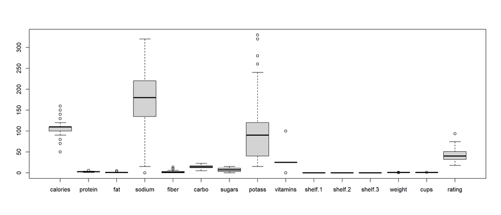

```r
boxplot(cer_N)
```

```r
# as we noticed that the range of most of variables is widly different and we don't want the algorithm to depend on an arbitrary variable unit so, we will Scale the data using function scale.
cer_scaled <- scale(cer_N)
head(cer_scaled)
```

```
##                             calories    protein        fat     sodium
## 100%_Bran                 -1.8659155  1.3817478  0.0000000 -0.3910227
## 100%_Natural_Bran          0.6537514  0.4522084  3.9728810 -1.7804186
## All-Bran                  -1.8659155  1.3817478  0.0000000  1.1795987
## All-Bran_with_Extra_Fiber -2.8737823  1.3817478 -0.9932203 -0.2702057
## Apple_Cinnamon_Cheerios    0.1498180 -0.4773310  0.9932203  0.2130625
## Apple_Jacks                0.1498180 -0.4773310 -0.9932203 -0.4514312
##                                 fiber      carbo     sugars     potass
## 100%_Bran                  3.22866747 -2.5001396 -0.2542051  2.5605229
## 100%_Natural_Bran         -0.07249167 -1.7292632  0.2046041  0.5147738
## All-Bran                   2.81602258 -1.9862220 -0.4836096  3.1248675
## All-Bran_with_Extra_Fiber  4.87924705 -1.7292632 -1.6306324  3.2659536
## Apple_Cinnamon_Cheerios   -0.27881412 -1.0868662  0.6634132 -0.4022862
## Apple_Jacks               -0.48513656 -0.9583868  1.5810314 -0.9666308
##                             vitamins   shelf.1    shelf.2    shelf.3     weight
## 100%_Bran                 -0.1818422 -0.583769 -0.6044546  1.0484407 -0.2008324
## 100%_Natural_Bran         -1.3032024 -0.583769 -0.6044546  1.0484407 -0.2008324
## All-Bran                  -0.1818422 -0.583769 -0.6044546  1.0484407 -0.2008324
## All-Bran_with_Extra_Fiber -0.1818422 -0.583769 -0.6044546  1.0484407 -0.2008324
## Apple_Cinnamon_Cheerios   -0.1818422  1.689858 -0.6044546 -0.9409083 -0.2008324
## Apple_Jacks               -0.1818422 -0.583769  1.6320274 -0.9409083 -0.2008324
##                                 cups     rating
## 100%_Bran                 -2.0856582  1.8549038
## 100%_Natural_Bran          0.7567534 -0.5977113
## All-Bran                  -2.0856582  1.2151965
## All-Bran_with_Extra_Fiber -1.3644493  3.6578436
## Apple_Cinnamon_Cheerios   -0.3038480 -0.9165248
## Apple_Jacks                0.7567534 -0.6553998
```

# Data Exploration

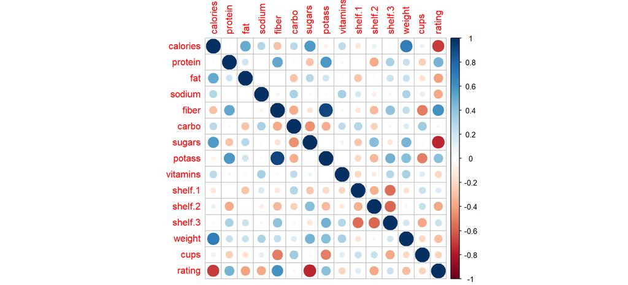

```r
library(corrplot)
cerealMat <- cor(cer_scaled)
corrplot(cerealMat, method = "circle")
```

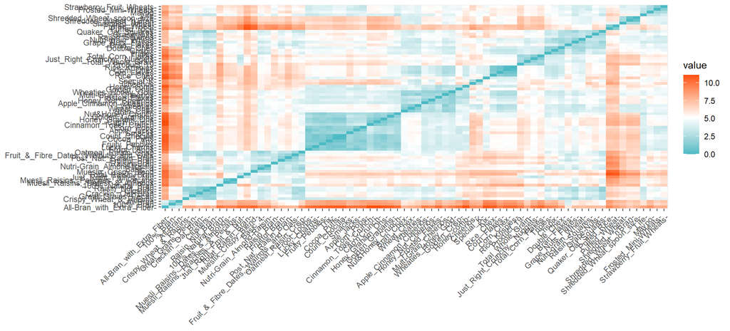

```r
distance <- get_dist(cer_scaled)
fviz_dist(distance, gradient = list(low = "#00AFBB", mid = "white", high = "#FC4E07"))
```

* we can notice that there is a strong positive relation between customer rating and (fiber, protein), while has a negative elation with (calories and sugars) * also we can notice the very strong positive relation between fiber and potass

## 1

# Hierarchical Clustering

- . Applying hierarchical clustering to the data using Euclidean distance to the normalized measurements.
- - Use Agnes to compare the clustering from single linkage, complete linkage, average linkage, and Ward. Choose the best method ?.
- Using the agnes function to get the agglomerative coefficient, which measures the amount of clustering structure found (values closer to 1 suggest strong clustering structure).
- This allows us to find certain hierarchical clustering methods that can identify stronger clustering structures.

```r
library(tidyverse)
```

```r
# methods to assess
m <- c("single", "complete", "average", "ward")
names(m) <- c("single", "complete", "average", "ward")
# function to compute coefficient
ac <- function(x) {
  agnes(cer_scaled, method = x)$ac}
map_dbl(m, ac)
```

```
##    single  complete   average      ward
## 0.6234190 0.8341098 0.7734558 0.9045198
```

- Here we see that Ward’s method identifies the strongest clustering structure of the four methods assessed.
- ward method - find the pair of clusters that leads to minimum increase in total within-cluster variance after merging

# Now Applying hierarchical clustering using Euclidean distance and Ward’s method

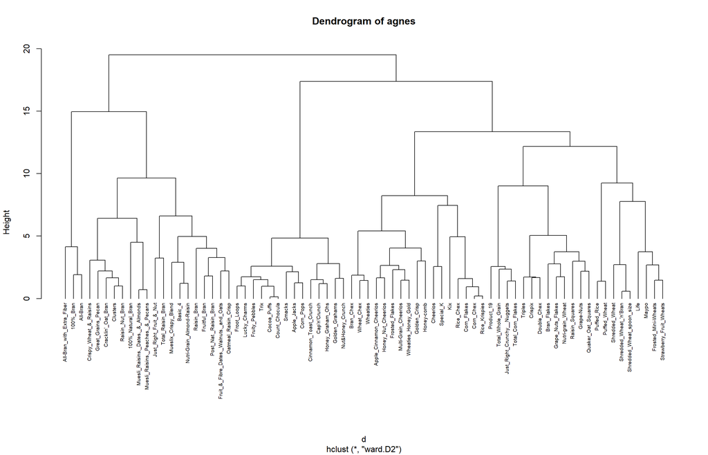

```r
library(stats)
# Apply hierarchical clustering to the data using Euclidean distance
d <- dist(cer_scaled, method = "euclidean")
# Similar to before we can visualize the dendrogram using ward:
hc <- hclust(d, method = "ward.D2")
plot(hc, cex = 0.6, hang = -1, main = "Dendrogram of agnes")
```

# B * Cutting the tree to 6 clusters, using the cutree() function

```r
# Cut tree into 6 groups
clusters <- cutree(hc, k = 6)
# Number of members in each cluster
table(clusters)
```

```
## clusters
##  1  2  3  4  5  6
##  3 18 17 14 13  9
```

```r
# Store the clusters in a data frame along with the cereals data
cereals_clusters <- cbind(clusters, cer_scaled)
```

```r
# Have a look at the head of the new data frame
colnames(cereals_clusters)[1] <- "clusters"
head(cereals_clusters)
```

```
##                           clusters   calories    protein        fat     sodium
## 100%_Bran                        1 -1.8659155  1.3817478  0.0000000 -0.3910227
## 100%_Natural_Bran                2  0.6537514  0.4522084  3.9728810 -1.7804186
## All-Bran                         1 -1.8659155  1.3817478  0.0000000  1.1795987
## All-Bran_with_Extra_Fiber        1 -2.8737823  1.3817478 -0.9932203 -0.2702057
## Apple_Cinnamon_Cheerios          3  0.1498180 -0.4773310  0.9932203  0.2130625
## Apple_Jacks                      4  0.1498180 -0.4773310 -0.9932203 -0.4514312
##                                 fiber      carbo     sugars     potass
## 100%_Bran                  3.22866747 -2.5001396 -0.2542051  2.5605229
## 100%_Natural_Bran         -0.07249167 -1.7292632  0.2046041  0.5147738
## All-Bran                   2.81602258 -1.9862220 -0.4836096  3.1248675
## All-Bran_with_Extra_Fiber  4.87924705 -1.7292632 -1.6306324  3.2659536
## Apple_Cinnamon_Cheerios   -0.27881412 -1.0868662  0.6634132 -0.4022862
## Apple_Jacks               -0.48513656 -0.9583868  1.5810314 -0.9666308
##                             vitamins   shelf.1    shelf.2    shelf.3     weight
## 100%_Bran                 -0.1818422 -0.583769 -0.6044546  1.0484407 -0.2008324
## 100%_Natural_Bran         -1.3032024 -0.583769 -0.6044546  1.0484407 -0.2008324
## All-Bran                  -0.1818422 -0.583769 -0.6044546  1.0484407 -0.2008324
## All-Bran_with_Extra_Fiber -0.1818422 -0.583769 -0.6044546  1.0484407 -0.2008324
## Apple_Cinnamon_Cheerios   -0.1818422  1.689858 -0.6044546 -0.9409083 -0.2008324
## Apple_Jacks               -0.1818422 -0.583769  1.6320274 -0.9409083 -0.2008324
##                                 cups     rating
## 100%_Bran                 -2.0856582  1.8549038
## 100%_Natural_Bran          0.7567534 -0.5977113
## All-Bran                  -2.0856582  1.2151965
## All-Bran_with_Extra_Fiber -1.3644493  3.6578436
## Apple_Cinnamon_Cheerios   -0.3038480 -0.9165248
## Apple_Jacks                0.7567534 -0.6553998
```

- We can display the dendrogram for hierarchical clustering, using the plot() function

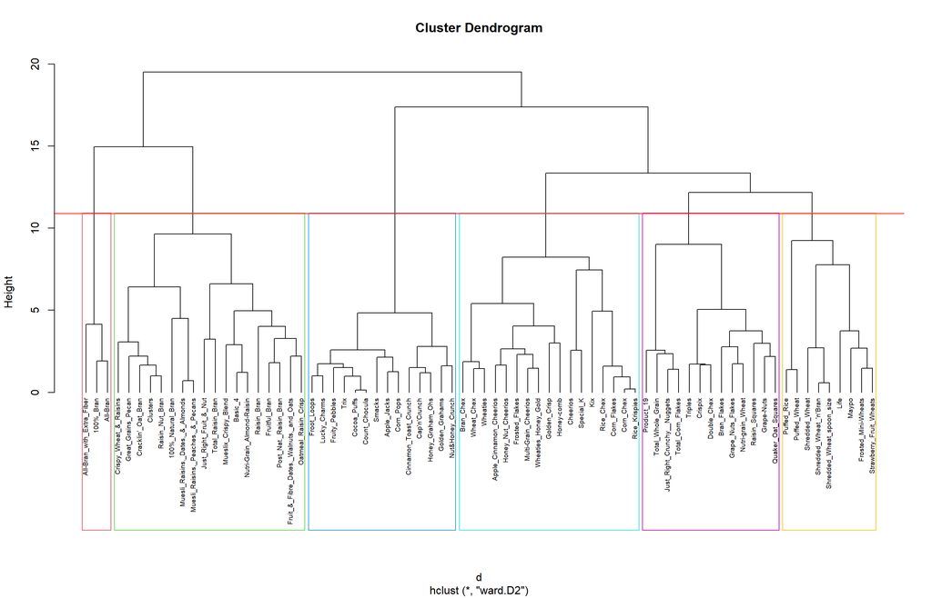

```r
plot(hc, cex= 0.6, hang = -1)
#Plot clusters being surrounded by a border, using the rect.hclust() function
rect.hclust(hc, k = 6, border = 2:7)
abline(h = 10.9, col = 'red')
```

we can also use the fviz_cluster function from the factoextra package to visualize the result in a scatter plot.

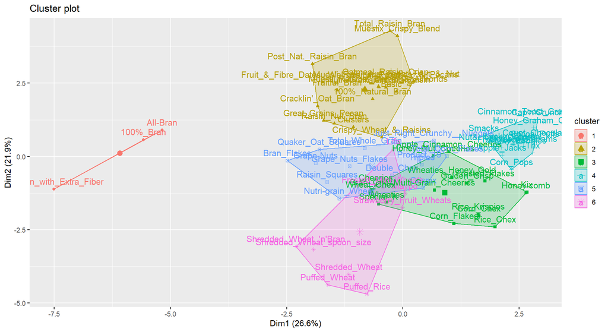

```r
fviz_cluster(list(data = cer_scaled, cluster = clusters))
```

## 2 # Determining Optimal Clusters. * Similar to how we determined optimal clusters with k-means clustering, we can execute similar approaches for hierarchical clustering: * lets use the following method ### Average Silhouette Method - The silhouette width/value is a measure of how similar an object is to its own cluster (cohesion) compared to other clusters (separation) [i.e., intra-cluster cohesion and inter-cluster separation] - Ranges from -1 to +1  
- Values closer to 1 means higher quality of the cluster created * To perform the average silhouette method we follow a similar process.

```r
set.seed(123)
library(cluster)
dist = daisy(x = cer_scaled, metric = "euclidean")
```

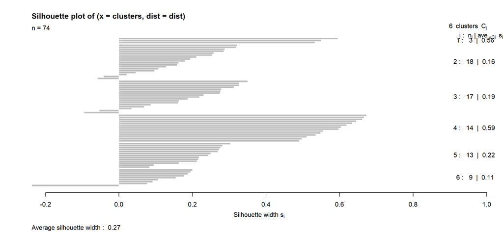

```r
sil_value = silhouette(clusters, dist = dist)
plot(sil_value)
```

### Now clustering data with k=4

```r
# Cut tree into 4 groups
clusters_4 <- cutree(hc, k = 4)
# Number of members in each cluster
table(clusters_4)
```

```
## clusters_4
##  1  2  3  4
##  3 18 39 14
```

```r
# Store the clusters in a data frame along with the cereals data
cereals_clusters_4 <- cbind(clusters_4, cer_scaled)
# Have a look at the head of the new data frame
colnames(cereals_clusters_4)[1] <- "clusters4"
head(cereals_clusters_4)
```

```
##                           clusters4   calories    protein        fat     sodium
## 100%_Bran                         1 -1.8659155  1.3817478  0.0000000 -0.3910227
## 100%_Natural_Bran                 2  0.6537514  0.4522084  3.9728810 -1.7804186
## All-Bran                          1 -1.8659155  1.3817478  0.0000000  1.1795987
## All-Bran_with_Extra_Fiber         1 -2.8737823  1.3817478 -0.9932203 -0.2702057
## Apple_Cinnamon_Cheerios           3  0.1498180 -0.4773310  0.9932203  0.2130625
## Apple_Jacks                       4  0.1498180 -0.4773310 -0.9932203 -0.4514312
##                                 fiber      carbo     sugars     potass
## 100%_Bran                  3.22866747 -2.5001396 -0.2542051  2.5605229
## 100%_Natural_Bran         -0.07249167 -1.7292632  0.2046041  0.5147738
## All-Bran                   2.81602258 -1.9862220 -0.4836096  3.1248675
## All-Bran_with_Extra_Fiber  4.87924705 -1.7292632 -1.6306324  3.2659536
## Apple_Cinnamon_Cheerios   -0.27881412 -1.0868662  0.6634132 -0.4022862
## Apple_Jacks               -0.48513656 -0.9583868  1.5810314 -0.9666308
##                             vitamins   shelf.1    shelf.2    shelf.3     weight
## 100%_Bran                 -0.1818422 -0.583769 -0.6044546  1.0484407 -0.2008324
## 100%_Natural_Bran         -1.3032024 -0.583769 -0.6044546  1.0484407 -0.2008324
## All-Bran                  -0.1818422 -0.583769 -0.6044546  1.0484407 -0.2008324
## All-Bran_with_Extra_Fiber -0.1818422 -0.583769 -0.6044546  1.0484407 -0.2008324
## Apple_Cinnamon_Cheerios   -0.1818422  1.689858 -0.6044546 -0.9409083 -0.2008324
## Apple_Jacks               -0.1818422 -0.583769  1.6320274 -0.9409083 -0.2008324
##                                 cups     rating
## 100%_Bran                 -2.0856582  1.8549038
## 100%_Natural_Bran          0.7567534 -0.5977113
## All-Bran                  -2.0856582  1.2151965
## All-Bran_with_Extra_Fiber -1.3644493  3.6578436
## Apple_Cinnamon_Cheerios   -0.3038480 -0.9165248
## Apple_Jacks                0.7567534 -0.6553998
```

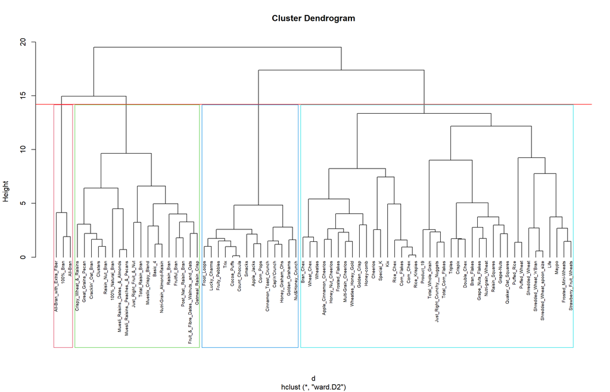

```r
plot(hc, cex= 0.6, hang = -1)
#Plot clusters being surrounded by a border, using the rect.hclust() function
rect.hclust(hc, k = 4, border = 2:7)
abline(h = 14.2, col = 'red')
```

## 3

### Comment on the structure of the clusters and on their stability. Hint: To check stability, partition the data and see how well clusters formed based on one part apply to the other part. To do this:

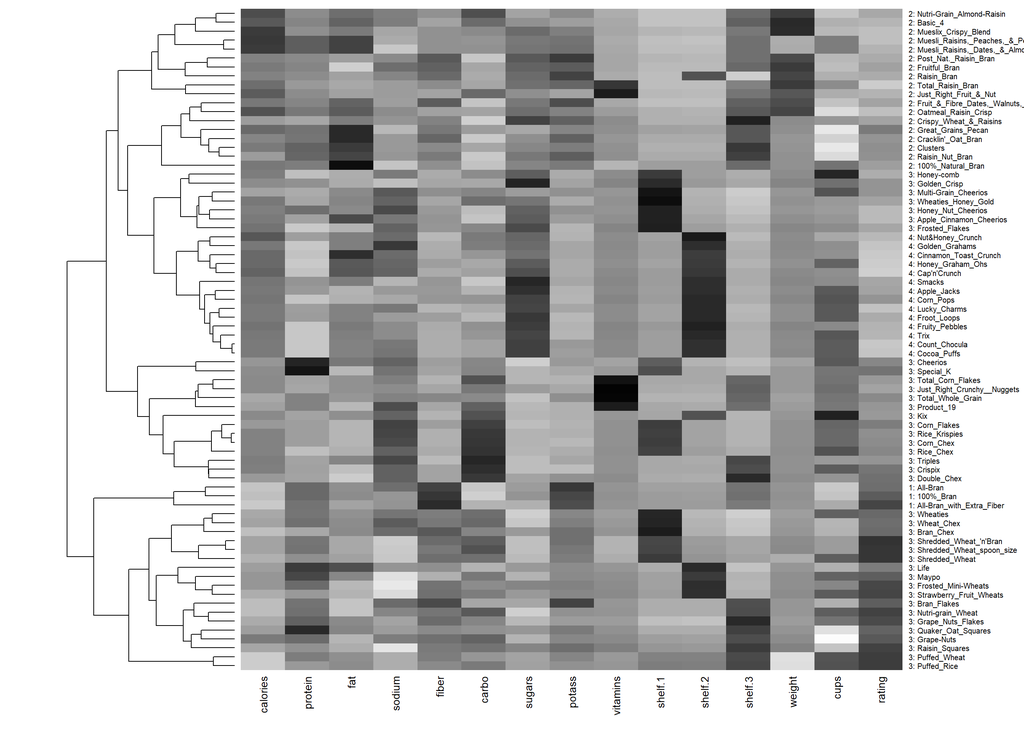

```r
# set labels as cluster membership and cereal name
row.names(cer_scaled) <- paste(clusters_4, ": ", row.names(cer_N), sep = "")

# plot heatmap to understand the structure of the data
# rev() reverses the color mapping to large = dark
heatmap(as.matrix(cer_scaled), Colv = NA, hclustfun = hclust,
        col=rev(paste("gray",1:99,sep="")))
```

- we can Visualize the characteristics of clusters of all data

```r
# claculating clutsrs centroids for all data clustering, using aggregate function
centroids_all <- aggregate(cer_scaled, by=list(cluster=clusters_4), mean)
library(hrbrthemes)
library(GGally)
library(viridis)
ggparcoord((centroids_all),
           columns = 1:16, groupColumn = 1,
           showPoints = TRUE,
           alphaLines = 0.3
)
```

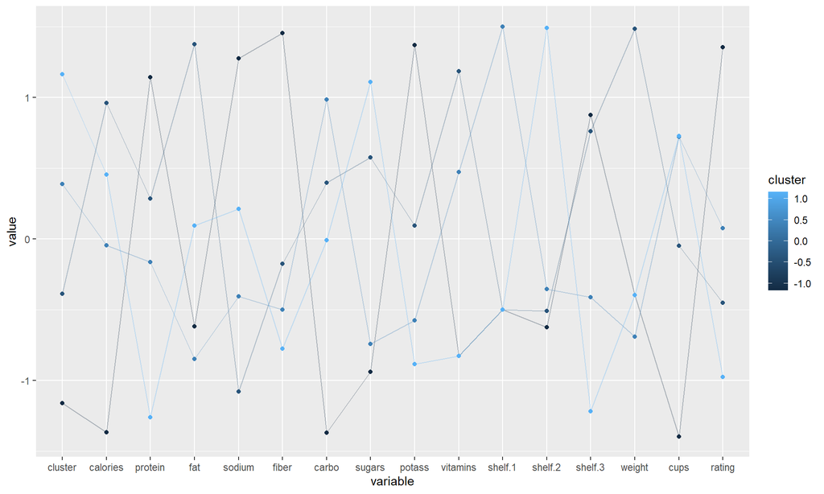

### Checking clusters’ stability.

- we will partiion the data to 2 groups A and B

```r
# partition 50% of data for A and 50% for B
library(caTools)
set.seed(123)   #  set seed to ensure we always have same random numbers generated
A<-cer_N[1:37,] # Partition A
B<-cer_N[38:74,] # Partition B

#Scaling datasets first
A_scaled <- scale(A)
B_scaled <- scale(B)
```

### Now clustering dataset A

- we will use thw same method for clustering and the same k = 4

```r
library(stats)
library(HAC)
```

```r
# Apply hierarchical clustering to the data using Euclidean distance
d_A <- dist(A_scaled, method = "euclidean")
# Similar to before we can visualize the dendrogram using ward:
hc_A <- hclust(d_A, method = "ward.D2")
# Cut tree into 4 groups
clust_A <- cutree(hc_A, k = 4)
# Number of members in each cluster
table(clust_A)
```

```
## clust_A
##  1  2  3  4
##  3 15  9 10
```

```r
# Store the clusters in a data frame along with the cereals data
cer_clust_A <- cbind(clust_A, A_scaled)
# Have a look at the head of the new data frame
colnames(cer_clust_A)[1] <- "clust_A"
head(cer_clust_A)
```

```
##                           clust_A   calories    protein         fat      sodium
## 100%_Bran                       1 -2.3133642  1.4806505 -0.06967121 -0.61541234
## 100%_Natural_Bran               2  0.9044732  0.5970365  3.36744200 -2.23181943
## All-Bran                        1 -2.3133642  1.4806505 -0.06967121  1.21183046
## All-Bran_with_Extra_Fiber       1 -3.6004992  1.4806505 -0.92894952 -0.47485520
## Apple_Cinnamon_Cheerios         3  0.2609057 -0.2865775  0.78960709  0.08737336
## Apple_Jacks                     4  0.2609057 -0.2865775 -0.92894952 -0.68569091
##                                fiber      carbo      sugars     potass
## 100%_Bran                  2.4823149 -2.2255275 -0.52084803  2.2521071
## 100%_Natural_Bran         -0.1418466 -1.4260662 -0.01370653  0.4594432
## All-Bran                   2.1542947 -1.6925533 -0.77441879  2.7466351
## All-Bran_with_Extra_Fiber  3.7943956 -1.4260662 -2.04227256  2.8702671
## Apple_Cinnamon_Cheerios   -0.3058567 -0.7598484  0.49343498 -0.3441647
## Apple_Jacks               -0.4698667 -0.6266048  1.50771799 -0.8386927
##                             vitamins    shelf.1    shelf.2    shelf.3    weight
## 100%_Bran                 -0.1031193 -0.5592328 -0.6415936  1.0698944 -0.290569
## 100%_Natural_Bran         -2.0108258 -0.5592328 -0.6415936  1.0698944 -0.290569
## All-Bran                  -0.1031193 -0.5592328 -0.6415936  1.0698944 -0.290569
## All-Bran_with_Extra_Fiber -0.1031193 -0.5592328 -0.6415936  1.0698944 -0.290569
## Apple_Cinnamon_Cheerios   -0.1031193  1.7398353 -0.6415936 -0.9094103 -0.290569
## Apple_Jacks               -0.1031193 -0.5592328  1.5164941 -0.9094103 -0.290569
##                                 cups     rating
## 100%_Bran                 -1.8191497  1.8894323
## 100%_Natural_Bran          0.8572136 -0.4073297
## All-Bran                  -1.8191497  1.2903756
## All-Bran_with_Extra_Fiber -1.1400724  3.5778031
## Apple_Cinnamon_Cheerios   -0.1414294 -0.7058841
## Apple_Jacks                0.8572136 -0.4613524
```

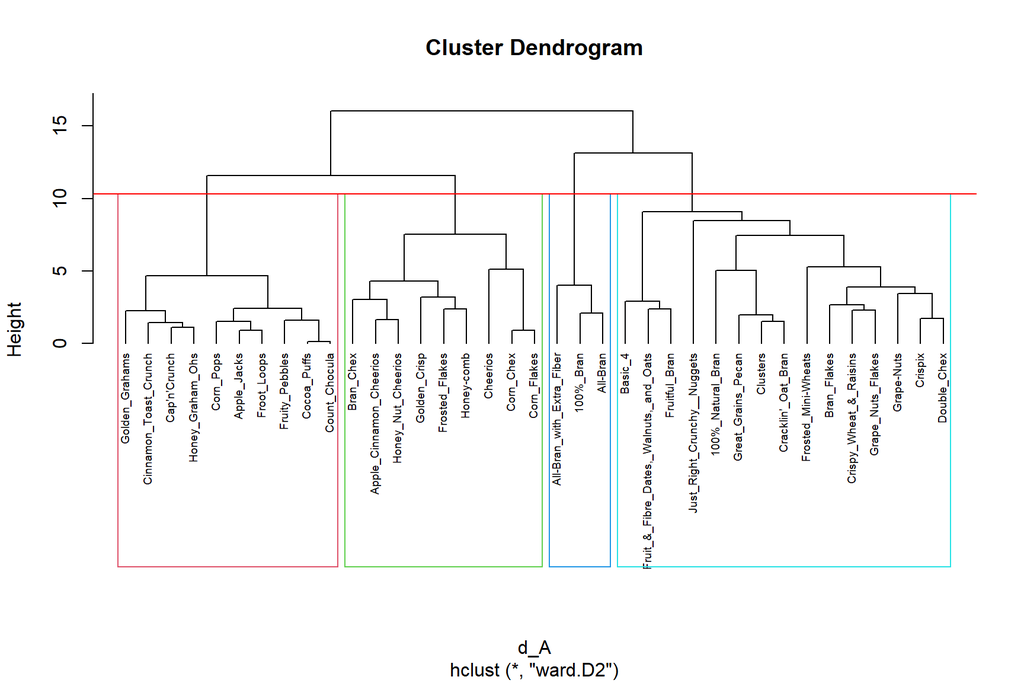

```r
plot(hc_A, cex= 0.6, hang = -1)
#Plot clusters being surrounded by a border, using the rect.hclust() function
rect.hclust(hc_A, k = 4, border = 2:7)
abline(h = 10.3, col = 'red')
```

### Calculating centroids of dataset A clusters

```r
# calculating cluters' centroids of partition A clusters, using aggregate function
centroids_A <- aggregate(A_scaled, by=list(cluster=clust_A), mean)
centroids_A
```

```
##   cluster    calories      protein        fat      sodium      fiber      carbo
## 1       1 -2.74240918  1.480650523 -0.3560973  0.04052098  2.8103350 -1.7813823
## 2       2  0.26090574  0.361406095  0.2167549 -0.36240949  0.1205696  0.2439197
## 3       3 -0.02512426  0.007960487 -0.3560973  0.54808842 -0.3969734  0.4689533
## 4       4  0.45397598 -0.993468738  0.1021844  0.03817836 -0.6666788 -0.2535229
##        sugars     potass   vitamins    shelf.1    shelf.2    shelf.3     weight
## 1 -1.11251313  2.6230031 -0.1031193 -0.5592328 -0.6415936  1.0698944 -0.2905690
## 2 -0.35180087  0.2286635  0.1512416 -0.5592328 -0.4977211  0.9379408  0.4261679
## 3 -0.09823011 -0.4540598 -0.1031193  1.7398353 -0.6415936 -0.9094103 -0.2905690
## 4  0.94986234 -0.7212423 -0.1031193 -0.5592328  1.5164941 -0.9094103 -0.2905690
##         cups     rating
## 1 -1.5927906  2.2525370
## 2 -0.3358319  0.2639343
## 3  0.5820319 -0.1303819
## 4  0.4577564 -0.9543189
```

- we can Visualize the characteristics of clusters of prtition A

```r
library(hrbrthemes)
library(GGally)
library(viridis)
ggparcoord((centroids_A),
           columns = 1:16, groupColumn = 1,
           showPoints = TRUE,
           alphaLines = 0.3
)
```

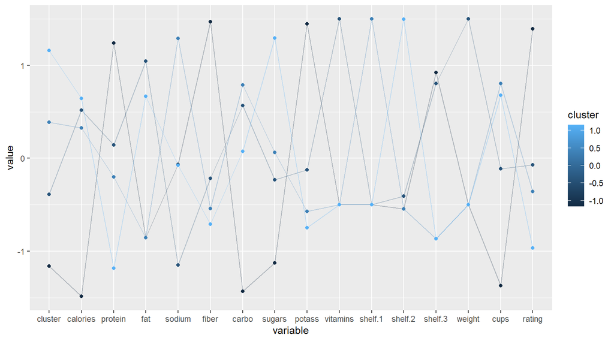

* now after we calculated the centroids of the clusters found by hierarchical clustering we will assign each observation of dataset B to the closest centroids of A clusters.

```r
# now we can assign observations of B partition to the clusters centroids of partition A.
Assign<-data.frame(observations=seq(1,37,1),cluster=rep(0,37))
for(i in 0:37)
{
  x<-as.data.frame(rbind(centroids_A[,-1],B_scaled[i,]))
  y<-as.matrix(get_dist(x))
  Assign[i,2]<-which.min(y[4,-4])
}
rownames(Assign) <-rownames(B_scaled)
Assign
```

```
##                                   observations cluster
## Just_Right_Fruit_&_Nut                       1       3
## Kix                                          2       4
## Life                                         3       4
## Lucky_Charms                                 4       4
## Maypo                                        5       3
## Muesli_Raisins,_Dates,_&_Almonds             6       3
## Muesli_Raisins,_Peaches,_&_Pecans            7       3
## Mueslix_Crispy_Blend                         8       3
## Multi-Grain_Cheerios                         9       4
## Nut&Honey_Crunch                            10       4
## Nutri-Grain_Almond-Raisin                   11       3
## Nutri-grain_Wheat                           12       3
## Oatmeal_Raisin_Crisp                        13       3
## Post_Nat._Raisin_Bran                       14       3
## Product_19                                  15       3
## Puffed_Rice                                 16       3
## Puffed_Wheat                                17       3
## Quaker_Oat_Squares                          18       3
## Raisin_Bran                                 19       3
## Raisin_Nut_Bran                             20       3
## Raisin_Squares                              21       3
## Rice_Chex                                   22       3
## Rice_Krispies                               23       3
## Shredded_Wheat                              24       3
## Shredded_Wheat_'n'Bran                      25       3
## Shredded_Wheat_spoon_size                   26       3
## Smacks                                      27       4
## Special_K                                   28       3
## Strawberry_Fruit_Wheats                     29       4
## Total_Corn_Flakes                           30       3
## Total_Raisin_Bran                           31       3
## Total_Whole_Grain                           32       3
## Triples                                     33       3
## Trix                                        34       4
## Wheat_Chex                                  35       3
## Wheaties                                    36       3
## Wheaties_Honey_Gold                         37       4
```

- we need to know which clusters the observations of partition B are assigned to.

```r
table(Assign)
```

```
##             cluster
## observations 3 4
##           1  1 0
##           2  0 1
##           3  0 1
##           4  0 1
##           5  1 0
##           6  1 0
##           7  1 0
##           8  1 0
##           9  0 1
##           10 0 1
##           11 1 0
##           12 1 0
##           13 1 0
```

[output cut: 24 more lines]

- as we noticed that the observations of partition B are assigned only to cluster 3 and cluster 4, with majority to cluster 3 this gives us an indication about the consistency and stability of those clusters
- now we will compare between the assignment of B observations to clusters of partition A and the whole data.

```r
cbind(A_partition=Assign$cluster,All_data=cereals_clusters_4[38:74,1])
```

```
##                                   A_partition All_data
## Just_Right_Fruit_&_Nut                      3        2
## Kix                                         4        3
## Life                                        4        3
## Lucky_Charms                                4        4
## Maypo                                       3        3
## Muesli_Raisins,_Dates,_&_Almonds            3        2
## Muesli_Raisins,_Peaches,_&_Pecans           3        2
## Mueslix_Crispy_Blend                        3        2
## Multi-Grain_Cheerios                        4        3
## Nut&Honey_Crunch                            4        4
## Nutri-Grain_Almond-Raisin                   3        2
## Nutri-grain_Wheat                           3        3
## Oatmeal_Raisin_Crisp                        3        2
## Post_Nat._Raisin_Bran                       3        2
## Product_19                                  3        3
## Puffed_Rice                                 3        3
## Puffed_Wheat                                3        3
## Quaker_Oat_Squares                          3        3
## Raisin_Bran                                 3        2
## Raisin_Nut_Bran                             3        2
## Raisin_Squares                              3        3
## Rice_Chex                                   3        3
## Rice_Krispies                               3        3
## Shredded_Wheat                              3        3
## Shredded_Wheat_'n'Bran                      3        3
## Shredded_Wheat_spoon_size                   3        3
## Smacks                                      4        4
## Special_K                                   3        3
## Strawberry_Fruit_Wheats                     4        3
## Total_Corn_Flakes                           3        3
## Total_Raisin_Bran                           3        2
## Total_Whole_Grain                           3        3
## Triples                                     3        3
## Trix                                        4        4
## Wheat_Chex                                  3        3
## Wheaties                                    3        3
## Wheaties_Honey_Gold                         4        3
```

```r
table(Assign$cluster==cereals_clusters_4[38:74,1])
```

```
##
## FALSE  TRUE
##    15    22
```

```r
#install.packages("fpc")
library(fpc)
set.seed(123)
#Input the scaled cereals_data
hclust_stability = clusterboot(cer_scaled, clustermethod=hclustCBI, method="ward.D2", k=4, count = FALSE)
hclust_stability
```

```
## * Cluster stability assessment *
## Cluster method:  hclust/cutree
## Full clustering results are given as parameter result
## of the clusterboot object, which also provides further statistics
## of the resampling results.
## Number of resampling runs:  100
##
## Number of clusters found in data:  4
##
##  Clusterwise Jaccard bootstrap (omitting multiple points) mean:
## [1] 0.4611412 0.7479811 0.6554305 0.9285665
## dissolved:
## [1] 61 11 28  6
## recovered:
## [1] 39 50 28 87
```